# ICMP data visualisation

Bevan Weir

Manaaki Whenua - Landcare Research

data as of 2 December 2021

## Introduction

This is an R Markdown document for statistics derived from specimen data of the ICMP culture collection https://www.landcareresearch.co.nz/icmp. This is an experimental showcase of presenting visualisations of data analysed in R in a user-friendly format.

```r
#import the files
ICMP.dump.initial <- read.csv("ICMP-export-2-dec-2021.csv", header=TRUE, sep=",")

#subset the data
#tidyverse way of sub setting - remove viruses and deaccessioned cultures
ICMP.dump <- ICMP.dump.initial %>%
  filter(SpecimenType == "Bacterial Culture" |
           SpecimenType == "Chromist Culture" |
           SpecimenType == "Fungal Culture" |
           SpecimenType == "Yeast Culture") %>%
  filter(Deaccessioned == "false")

#how many cultures are public
ICMP.public <- ICMP.dump.initial %>%
  filter(SpecimenSecurityLevelText == "Public")
```

## General statistics

The ICMP database has 22984 entries, removing cultures that have died and are no longer available (‘deaccessioned’) there are **22265 cultures**. This total includes cultures stored privately not available to the public, and those in the process of storage. The total number of publicly available cultures is 19568. Most of the stats below use the ‘total minus deaccessioned’ number as the base data.

(also should include NZ only stats)

```r
#ktable.specimen2 <- count(ICMP.dump,SpecimenType) #dpylr
#kable(ktable.specimen2, caption = "Basic stats") #knitr

#table of specimen types
#table.stypes <- ICMP.dump %>%
#  group_by(SpecimenType) %>%
#  tally()
#kbl(table.stypes, caption = "table of specimen types") %>%
#kable_paper("hover", full_width = F) #can use striped instead of hover
```

## Type cultures

```r
ICMP.types <- subset(ICMP.dump,!(TypeStatus == ""))
```

The ICMP has **948 type cultures** cultures, these consist of:

```r
table(ICMP.types$SpecimenType)
```

```
##
## Bacterial Culture  Chromist Culture    Fungal Culture     Yeast Culture
##               580                13               351                 4
```

There are different ‘kinds’ of types. Bacterial types are ‘type strains’, bacterial pathovars are ‘pathotype strains’. Fungal type cultures may have been isolated from a type specimen (e.g. from PDD) and are thus ‘ex types’.

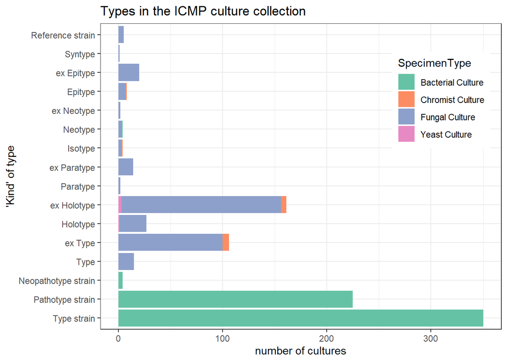

```r
#barchart of all ICMP types sorted by 'kind' of type, coloured by kind of organism
positions <- c("Type strain", "Pathotype strain", "Neopathotype strain", "Type", "ex Type",  "Holotype", "ex Holotype", "Paratype", "ex Paratype", "Isotype", "Neotype", "ex Neotype", "Epitype", "ex Epitype", "Syntype", "Reference strain")
ggplot(ICMP.types, aes(TypeStatus, fill=SpecimenType)) +
  labs(title = "Types in the ICMP culture collection") +
  labs(x = "'Kind' of type", y = "number of cultures") +
  geom_bar() +
  coord_flip() +
  theme_bw()+
  theme(legend.position = c(0.85, 0.75)) +
  scale_fill_brewer(palette = "Set2") +
  scale_x_discrete(limits = positions)
```

## Extended specimen data

Extended specimen data is data beyond the basic taxonomic and and location. See: https://academic.oup.com/bioscience/article/70/1/23/5637849 The charts below show the proportion of ICMP cultures that have DNA sequences lodged in GenBank global repository, images (usually of culture plates), and when a culture is specifically cited in literature.

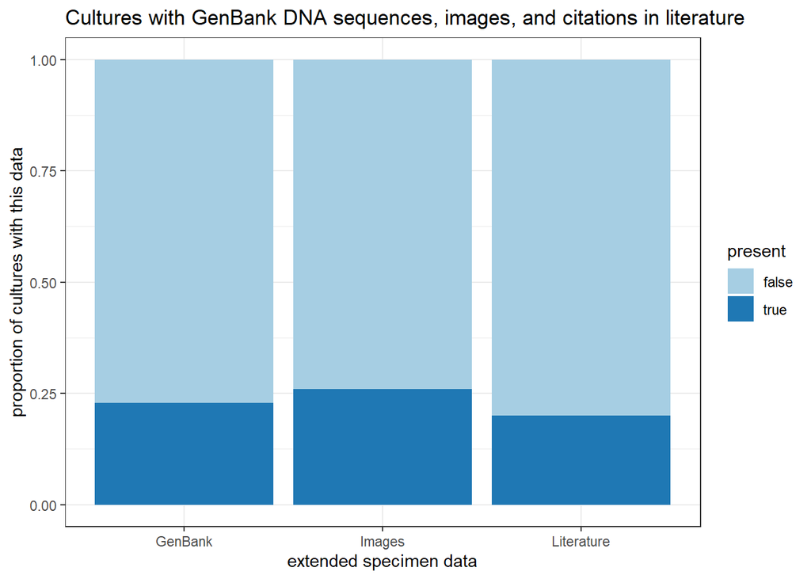

```r
#sub set out the interesting columns using "select" in dpylr
library(dplyr)
only.ext.specimen <- select(ICMP.dump, "AccessionNumber","SpecimenType", "GenBank", "Literature", "Images")

#create two new columns using "pivot_longer" into a tibble table
library(tidyr)
tibble.ext.specimen <-pivot_longer(only.ext.specimen, cols=3:5, names_to="ExtendedSpecimen", values_to="present")

# ** Cultures with extended specimen data
ggplot(tibble.ext.specimen, aes(ExtendedSpecimen, fill=present)) +
  labs(title = "Cultures with GenBank DNA sequences, images, and citations in literature") +
  labs(x = "extended specimen data", y = "proportion of cultures with this data") +
  theme_bw() +
  scale_fill_brewer(palette = "Paired") +
  geom_bar(position = "fill")
```

This data can be split by the type of specimen (Bacteria, Fungi, Chromist, Yeast) to show the relative proportions of extended specimen data for each of these.

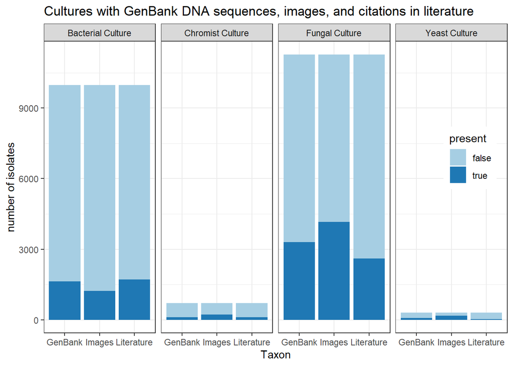

```r
# ** Cultures with extended specimen data by ExtendedSpecimen with SpecimenType facet
ggplot(tibble.ext.specimen, aes(ExtendedSpecimen, fill=present)) +
  labs(title = "Cultures with GenBank DNA sequences, images, and citations in literature") +
  labs(x = "Taxon", y = "number of isolates") +
  scale_fill_brewer(palette = "Paired") +
  geom_bar() +
  theme_bw() +
  theme(legend.position = c(0.92, 0.6)) +
  facet_grid(cols = vars(SpecimenType))
```

## Host plants

Many ICMP cultures are associated with a host plant, for example rhizobia in legume nodules, or plant pathogenic fungi causing leaf spots. Below are the top 10 most common host plant families in the ICMP with type of organism.

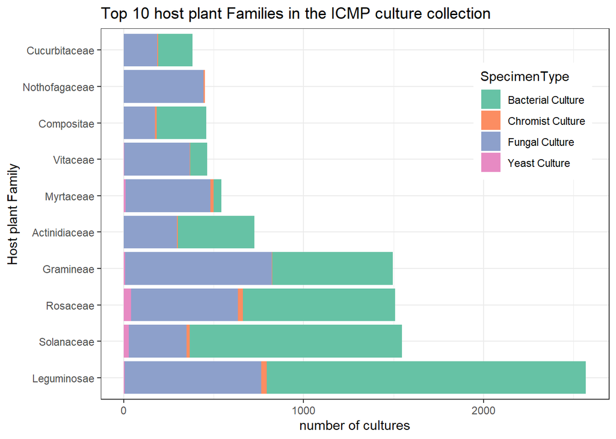

```r
#barchart of to 10 host families sorted by 'kind' of type, coloured by kind of organism
positions.10hosts <- c("Leguminosae", "Solanaceae", "Rosaceae", "Gramineae", "Actinidiaceae", "Myrtaceae", "Vitaceae", "Compositae", "Nothofagaceae",  "Cucurbitaceae")
ICMP.10hosts <- subset(ICMP.dump, (Family_C2 == "Leguminosae" | Family_C2 == "Solanaceae" | Family_C2 == "Rosaceae" | Family_C2 == "Gramineae" | Family_C2 == "Actinidiaceae" | Family_C2 == "Myrtaceae" | Family_C2 == "Vitaceae" | Family_C2 == "Compositae" | Family_C2 == "Nothofagaceae" | Family_C2 == "Cucurbitaceae"))

ggplot(ICMP.10hosts, aes(Family_C2, fill=SpecimenType)) +
  labs(title = "Top 10 host plant Families in the ICMP culture collection") +
  labs(x = "Host plant Family", y = "number of cultures") +
  geom_bar() +
  coord_flip() +
  theme_bw() +
  theme(legend.position = c(0.85, 0.75)) +
  scale_fill_brewer(palette = "Set2") +
  scale_x_discrete(limits = positions.10hosts)
```

## Geography

ICMP cultures have been isolated from around the world.

### World distribution

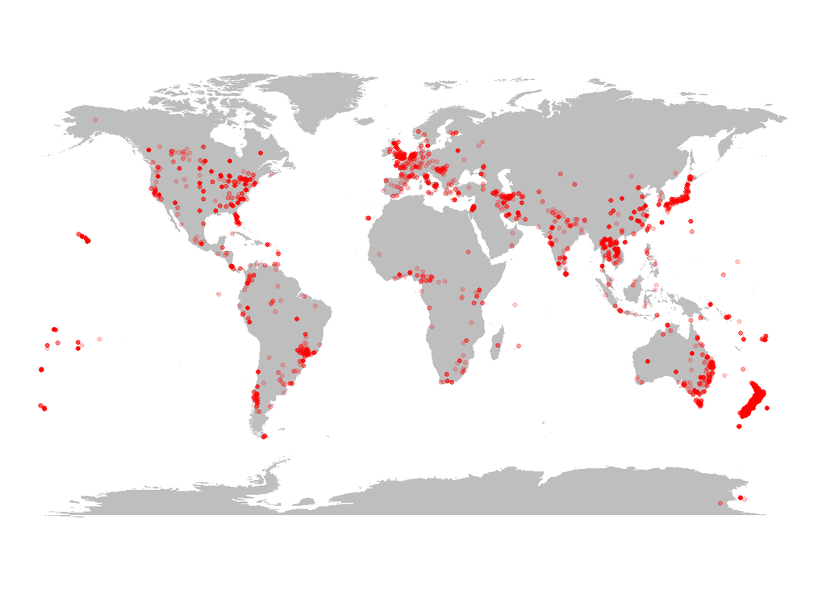

```r
world <- map_data("world")
ggplot() +
  geom_polygon(data = world, aes(x=long, y = lat, group = group), fill = "grey") +
  theme_void() +
  geom_point(data = ICMP.dump, aes(x = DecimalLong, y = DecimalLat), color = "red", size = 1, alpha = 0.2) +
  coord_fixed(1.3)
```

The top 10 countries represented in the ICMP with type of samples are shown below.

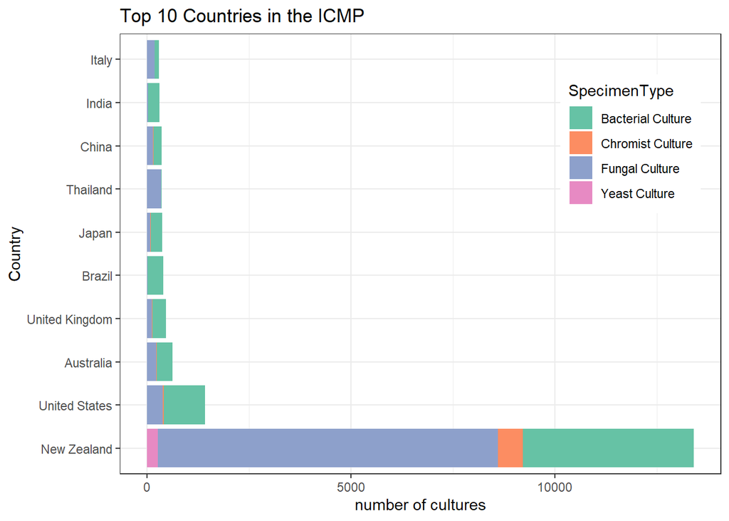

```r
positions <- c("New Zealand", "United States", "Australia", "United Kingdom", "Brazil", "Japan", "Thailand", "China", "India",  "Italy")

ICMP.10county <- subset(ICMP.dump, (Country == "New Zealand" | Country == "United States" | Country == "Australia" | Country == "United Kingdom" | Country == "Brazil" | Country == "Thailand" | Country == "China" | Country == "Japan" | Country == "India" | Country == "Italy"))

ggplot(ICMP.10county, aes(Country, fill=SpecimenType)) +
  labs(title = "Top 10 Countries in the ICMP") +
  labs(x = "Country", y = "number of cultures") +
  theme(axis.text.x=element_text(angle=-90, hjust=0)) +
  geom_bar() +
  coord_flip() +
  theme_bw() +
  theme(legend.position = c(0.85, 0.75)) +
  scale_fill_brewer(palette = "Set2") +
  scale_x_discrete(limits = positions)
```

### New Zealand distribution

Each of the cultures from New Zealand that have a geocoordinate are plotted below. A better interative map can be found on GBIF at: https://www.gbif.org/dataset/3c6e7390-3b56-11dc-8c19-b8a03c50a862.

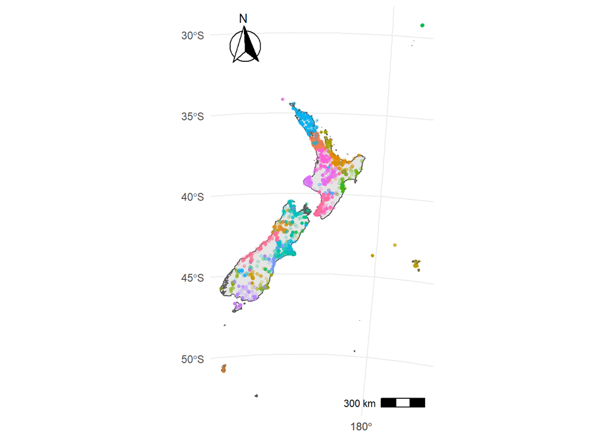

There are various ways to divide Aotearoa New Zealand in regions. The ICMP uses ‘Crosby Codes’ which were developed for for recording specimen localities in the New Zealand. The ICMP is based in Auckland explaining the large number of collections from this region.

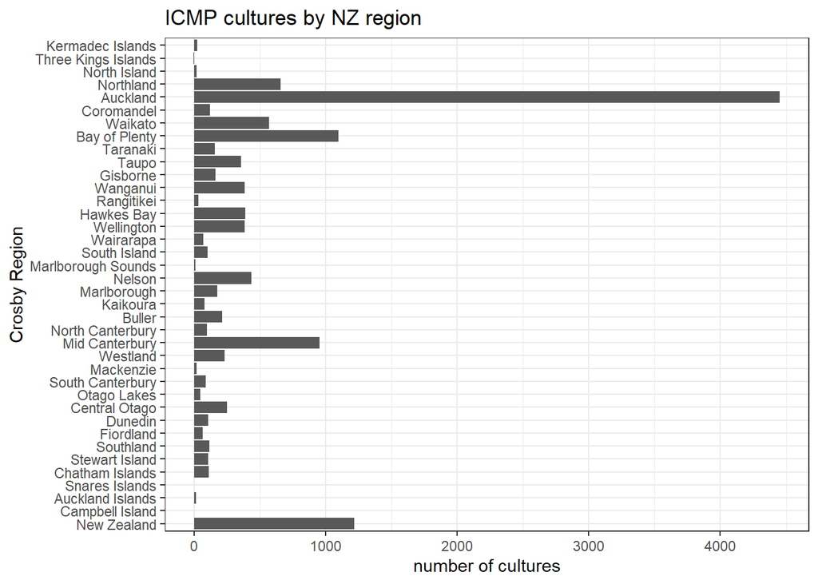

```r
#New Zealand Area codes
ICMP.NZ <- subset(ICMP.dump,(Country == "New Zealand"))

positions <- c("New Zealand", "Campbell Island", "Auckland Islands", "Snares Islands", "Chatham Islands",  "Stewart Island", "Southland", "Fiordland", "Dunedin", "Central Otago", "Otago Lakes", "South Canterbury", "Mackenzie", "Westland", "Mid Canterbury", "North Canterbury", "Buller", "Kaikoura", "Marlborough", "Nelson", "Marlborough Sounds", "South Island", "Wairarapa", "Wellington", "Hawkes Bay", "Rangitikei", "Wanganui", "Gisborne", "Taupo", "Taranaki", "Bay of Plenty", "Waikato", "Coromandel", "Auckland", "Northland", "North Island", "Three Kings Islands", "Kermadec Islands")

ggplot(ICMP.NZ, aes(NZAreaCode)) +
  labs(title = "ICMP cultures by NZ region") +
  labs(x = "Crosby Region", y = "number of cultures") +
  theme(axis.text.x=element_text(angle=-90, hjust=0)) +
  geom_bar() +
  theme_bw() +
  coord_flip() +
  scale_x_discrete(limits = positions)
```

## Timeline

```r
#this is just for data checking e.g. ranking the eary ones don't display in the final version

#all cultures sorted by date. Add a new column date.isolated
ICMP.dump$date.isolated <- ymd(ICMP.dump$IsolationDateISO, truncated = 3)
arrange(ICMP.dump, date.isolated) %>%
  select("AccessionNumber","SpecimenType", "Country", "date.isolated") %>%
  slice_head(n=5)
```

```
##   AccessionNumber      SpecimenType       Country date.isolated
## 1       ICMP 1580 Bacterial Culture        Canada    1901-08-01
## 2       ICMP 3970 Bacterial Culture United States    1915-01-01
## 3       ICMP 5760 Bacterial Culture United States    1917-01-01
## 4        ICMP 336 Bacterial Culture United States    1917-01-01
## 5       ICMP 1386 Bacterial Culture        Canada    1918-01-01
```

```r
#all cultures sorted by deposited date. Add a new column date.isolated
ICMP.dump$date.deposited <- ymd(ICMP.dump$DepositedDateISO, truncated = 3)
arrange(ICMP.dump, date.deposited) %>%
  select("AccessionNumber","SpecimenType", "Country", "date.deposited") %>%
  slice_head(n=5)
```

```
##   AccessionNumber      SpecimenType     Country date.deposited
## 1        ICMP 146    Fungal Culture New Zealand     1962-04-01
## 2        ICMP 147    Fungal Culture New Zealand     1962-04-01
## 3        ICMP 148    Fungal Culture New Zealand     1962-04-01
## 4          ICMP 1 Bacterial Culture New Zealand     1962-05-01
## 5          ICMP 2 Bacterial Culture New Zealand     1962-05-01
```

```r
#New Zealand cultures sorted by date. Add a new column date.isolated
ICMP.NZ$date.isolated <- ymd(ICMP.NZ$IsolationDateISO, truncated = 3)
arrange(ICMP.NZ, date.isolated) %>%
  select("AccessionNumber","SpecimenType", "Country", "date.isolated") %>%
  slice_head(n=5)
```

```
##   AccessionNumber      SpecimenType     Country date.isolated
## 1       ICMP 1322 Bacterial Culture New Zealand    1927-01-01
## 2       ICMP 1805 Bacterial Culture New Zealand    1927-01-01
## 3      ICMP 13879    Fungal Culture New Zealand    1946-06-01
## 4         ICMP 27 Bacterial Culture New Zealand    1949-01-01
## 5        ICMP 342     Yeast Culture New Zealand    1949-01-01
```

- The earliest culture in ICMP is [*Erwinia* sp. ICMP 1580](https://scd.landcareresearch.co.nz/Specimen/ICMP_1580) isolated in 1901 from Canada
- The earliest New Zealand bacteria culture is [*Sinorhizobium meliloti* ICMP 1322](https://scd.landcareresearch.co.nz/Specimen/ICMP_1322) isolated in 1927
- The earliest New Zealand fungal culture is [*Fuscoporia contigua* ICMP 13879](https://scd.landcareresearch.co.nz/Specimen/ICMP_13879) isolated in 1946
- The earliest New Zealand yeast culture is [*Saccharomyces cerevisiae* ICMP 342](https://scd.landcareresearch.co.nz/Specimen/ICMP_342) isolated in 1949

### Isolations and deposits over time

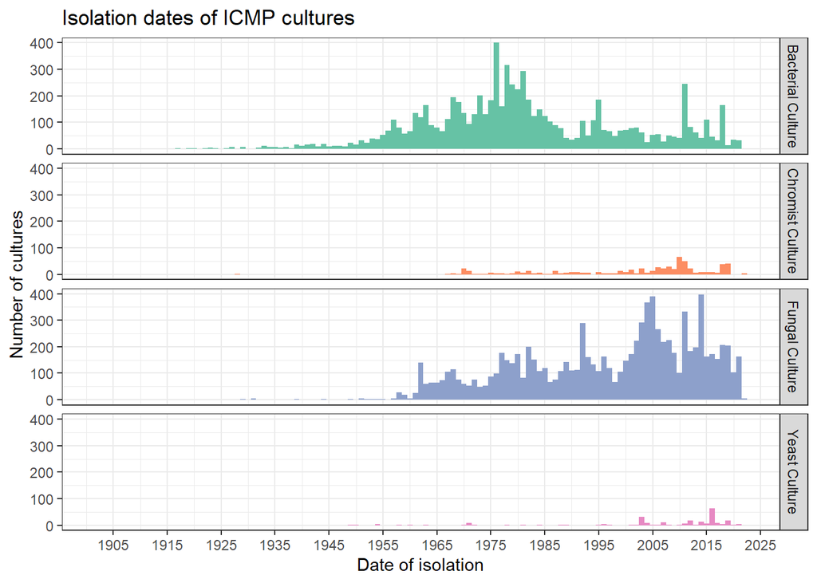

```r
#standard all ICMP overtime stats faceted

date.isolated <-ymd(ICMP.dump$IsolationDateISO, truncated = 3)
ggplot(ICMP.dump, aes(date.isolated, fill = SpecimenType)) +
  labs(title = "Isolation dates of ICMP cultures") +
  labs(x = "Date of isolation", y =  "Number of cultures" , fill = "") +
  scale_fill_brewer(palette = "Set2") +
  scale_x_date(date_breaks = "10 years", date_labels = "%Y") +
  theme_bw() +
  geom_histogram(binwidth=365.25, show.legend = FALSE) +
  facet_grid(SpecimenType ~ ., scales = "fixed")
```

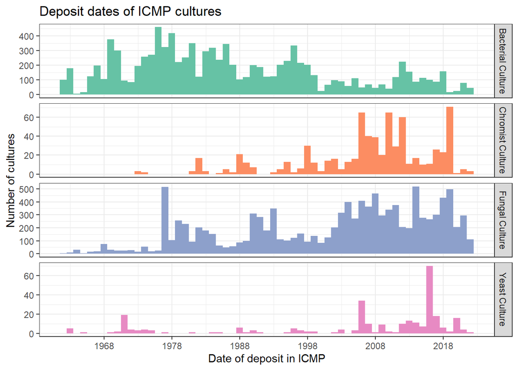

```r
#ICMP deposit date faceted
date.deposited <-ymd(ICMP.dump$DepositedDateISO, truncated = 3)
ggplot(ICMP.dump, aes(date.deposited, fill = SpecimenType)) +
  labs(title = "Deposit dates of ICMP cultures") +
  labs(x = "Date of deposit in ICMP", y =  "Number of cultures" , fill = "") +
  scale_fill_brewer(palette = "Set2") +
  scale_x_date(date_breaks = "10 years", date_labels = "%Y") +
  theme_bw() +
  geom_histogram(binwidth=365.25, show.legend = FALSE) + # this is a bin of two years: binwidth=730
  facet_grid(SpecimenType ~ ., scales = "free")
```

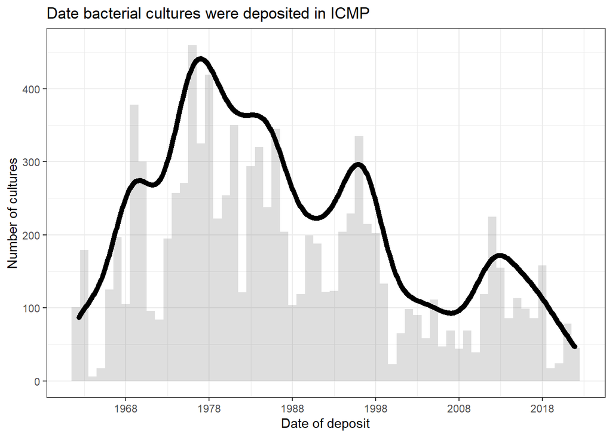

```r
ICMP.bacteria <- subset(ICMP.dump,(SpecimenType == "Bacterial Culture"))

ICMP.bacteria$date.deposited <- ymd(ICMP.bacteria$DepositedDateISO, truncated = 3)
ggplot(ICMP.bacteria, aes(date.deposited)) +
  theme_bw() +
  labs(title = "Date bacterial cultures were deposited in ICMP") +
  labs(x = "Date of deposit", y =  "Number of cultures" , fill = "") +
  scale_x_date(date_breaks = "10 years", date_labels = "%Y") +
  theme_bw() +
  geom_histogram(binwidth=365.25, alpha = 0.2) +
  geom_density(aes(y=500 * ..count..), size = 2) #multiplies the density by 500x so it is visible
```

### Isolation month

In the New Zealand autumn, May is the peak mushroom fruiting season explain the number of fungi isolated in this month. In general there is a trend of fewer isolations in Winter and more in Summer. The high numbers in January may be an artifact of a prior way recording the data in the database which if the month was unknown it would be recorded as January.

less in winter, more in summer trend.

```r
#new month ICMP culture isolated (in NZ)
attach(ICMP.NZ)
```

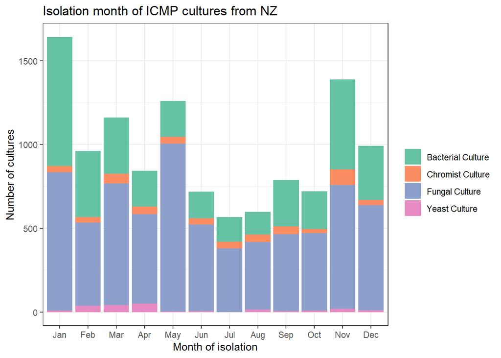

```r
month.isolated <- ymd(ICMP.NZ$IsolationDateISO, truncated = 1)
mergemonths <- floor_date(month.isolated, unit = "month")
ggplot(ICMP.NZ, aes(month(mergemonths, label = TRUE), fill = SpecimenType)) +
  labs(title = "Isolation month of ICMP cultures from NZ") +
  labs(x = "Month of isolation", y =  "Number of cultures" , fill = "") +
  scale_fill_brewer(palette = "Set2") +
  theme_bw() +
  geom_bar() +
  scale_x_discrete(na.translate = FALSE)  # this removes NAs
```

## People

Top 10 collectors, isolators, identifiers. This will be better once we get the agents module working, which will reduce the duplicates. Will convert to charts at that time.

```r
sort(table(ICMP.dump$StandardCollector),decreasing=TRUE)[1:12] #top 12 StandardCollector
```

```
##
##               Watson, DRW    Young, JM Johnston, PR  Dingley, JM    [Unknown]
##         8209         1114          682          665          561          523
##   Laundon, G   Cooper, JA      Dye, DW   Beever, RE     Hill, CF  Laundon, GF
##          308          250          236          234          216          207
```

```r
sort(table(ICMP.dump$StandardDeterminer),decreasing=TRUE)[1:11] #top 11 StandardDeterminer
```

```
##
##                                  Johnston, PR               Weir, BS
##                  15573                   1416                   1415
##             Weir, B.S.             Cooper, JA              Probst, C
##                    712                    173                    127
##         Thambugala, KM           Thangavel, R Chanintorn Doungsa-ard
##                    101                     97                     91
##         Braithwaite, M            Rahimian, H
##                     87                     75
```

```r
sort(table(ICMP.dump$DepositorName),decreasing=TRUE)[1:11] #top 11 DepositorName
```

```
##
##        D.W. Dye   P.R. Johnston   D.R.W. Watson      J.M. Young       C.F. Hill
##            1310            1298            1211             966             771
##    J.M. Dingley     R.E. Beever           NCPPB   P.K. Buchanan E.H.C. McKenzie
##             694             632             510             449             417
##      G. Laundon
##             406
```

## Curation stats

These stats may be useful for curation or data checking for ICMP staff.

### Last updated user

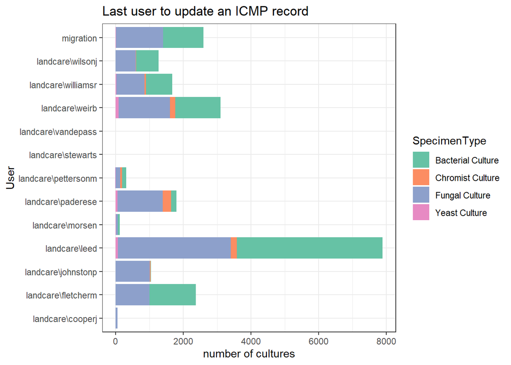

```r
#pie chart by last updated user
#ICMP.dump$LastUpdatedBy <- sapply(ICMP.dump$UpdatedBy, tolower)
#ggplot(ICMP.dump, aes(x=factor(1), fill=LastUpdatedBy)) +
#  labs(title = "Last user to update an ICMP record") +
#  geom_bar(width = 1) +
#  coord_polar("y") +
#  theme_void() +
#  scale_fill_brewer(palette = "Paired")

ICMP.dump$LastUpdatedBy <- sapply(ICMP.dump$UpdatedBy, tolower)
ggplot(ICMP.dump, aes(LastUpdatedBy, fill = SpecimenType)) +
  labs(title = "Last user to update an ICMP record") +
  labs(x = "User", y = "number of cultures") +
  theme(axis.text.x=element_text(angle=-90, hjust=0)) +
  theme_bw() +
  geom_bar() +
  scale_fill_brewer(palette = "Set2") +
  coord_flip()
```

### Security levels

```r
#table of security levels
table.security <- ICMP.dump %>%
  group_by(SpecimenSecurityLevelText) %>%
  tally()
kable(table.security, caption = "table of security levels") #knitr
```

table of security levels

| SpecimenSecurityLevelText | n |
| --- | --- |
| Collection Staff Only | 426 |
| Confidential | 282 |
| Public | 19540 |
| Registered Users | 7 |
| Systematics Researchers | 2010 |

### Biostatus

```r
#table of security levels
table.security <- ICMP.dump %>%
  group_by(OccurrenceDescription) %>%
  tally()
kable(table.security, caption = "table of biostatus Occurrence") #knitr
```

table of biostatus Occurrence

| OccurrenceDescription | n |
| --- | --- |
|  | 732 |
| Absent | 2456 |
| Border intercept | 54 |
| Eradicated | 116 |
| Present | 18512 |
| Present in captivity/cultivation/culture | 36 |
| Recorded in error | 105 |
| Uncertain | 254 |

```r
#table of security levels
table.security <- ICMP.dump %>%
  group_by(BiostatusDescription) %>%
  tally()
kable(table.security, caption = "table of biostatus description") #knitr
```

table of biostatus description

| BiostatusDescription | n |
| --- | --- |
|  | 12316 |
| Endemic | 453 |
| Exotic | 6826 |
| Exotic Fully Naturalised | 6 |
| Indigenous | 183 |
| Non-endemic | 1055 |
| Uncertain | 1426 |

```r
#knitr::include_url("https://public.flourish.studio/visualisation/7745803/")
```

### Head of the dataset

This table shows the first few rows of the full dataset. use the arrows to explore across the columns.

```r
 rmarkdown::paged_table(head(ICMP.dump))
```

|  | AccessionNumber | SpecimenType | FilingNumber | SpecimenSecurityLevel | SpecimenSecurityLevelText | Deaccessioned | IsMissing | LoanStatus | CreatedBy | CreatedDate | UpdatedBy | UpdatedDate | Quantity | TypeStatus | VerbatimName | TaxonName | CurrentName | SourceNameId | VerbatimDeterminer | StandardDeterminer | DeterminersRefNumber | Phylum | Class | Order | Family | PartAffected | Substrate | BiostatusDescription | OccurrenceDescription | … |
| --- | --- | --- | --- | --- | --- | --- | --- | --- | --- | --- | --- | --- | --- | --- | --- | --- | --- | --- | --- | --- | --- | --- | --- | --- | --- | --- | --- | --- | --- | --- |
| 1 | ICMP 593 | Bacterial Culture | Xanthomonadaceae | 40 | Public | false | false |  | Migration | 25/01/2002 9:24:09 am | LANDCARE\\wilsonj | 19/04/2018 3:52:03 pm | NA |  | Xanthomonas campestris pv. campestris (Pammel 1895) Dowson 1939 | Xanthomonas campestris pv. campestris | Xanthomonas campestris pv. campestris | 7A340EEC-10CE-4CA1-A7A1-561A65C970F3 |  |  |  | "Proteobacteria" | Gammaproteobacteria | Xanthomonadales | Xanthomonadaceae | leaf vein |  |  | Present | … |
| 2 | ICMP 594 | Bacterial Culture | Xanthomonadaceae | 40 | Public | false | false |  | Migration | 25/01/2002 9:24:09 am | LANDCARE\\LeeD | 17/08/2020 12:47:16 pm | 1 |  | Xanthomonas campestris pv. citri (Hasse 1915) Dye 1978 | Xanthomonas campestris pv. citri | Xanthomonas citri subsp. citri | 5AFC580F-3FA1-4638-95D2-DBEAA368B85A |  |  |  | "Proteobacteria" | Gammaproteobacteria | Xanthomonadales | Xanthomonadaceae | fruit |  | Exotic | Eradicated | … |
| 3 | ICMP 607 | Bacterial Culture | Xanthomonadaceae | 40 | Public | false | false |  | Migration | 25/01/2002 9:24:09 am | LANDCARE\\LeeD | 17/08/2020 12:47:55 pm | 1 |  | Xanthomonas campestris pv. citri (Hasse 1915) Dye 1978 | Xanthomonas campestris pv. citri | Xanthomonas citri subsp. citri | 5AFC580F-3FA1-4638-95D2-DBEAA368B85A |  |  |  | "Proteobacteria" | Gammaproteobacteria | Xanthomonadales | Xanthomonadaceae | fruit |  | Exotic | Eradicated | … |
| 4 | ICMP 608 | Bacterial Culture | Xanthomonadaceae | 40 | Public | false | false |  | Migration | 25/01/2002 9:24:09 am | LANDCARE\\LeeD | 17/08/2020 12:48:28 pm | NA |  | Xanthomonas campestris pv. pruni (Smith 1903) Dye 1978 | Xanthomonas campestris pv. pruni | Xanthomonas arboricola pv. pruni | 06AF8B3E-E455-4A0F-8E9A-5850DD751752 |  |  |  | "Proteobacteria" | Gammaproteobacteria | Xanthomonadales | Xanthomonadaceae | canker |  | Exotic | Present | … |
| 5 | ICMP 609 | Bacterial Culture | Xanthomonadaceae | 40 | Public | false | false |  | Migration | 25/01/2002 9:24:09 am | LANDCARE\\LeeD | 17/08/2020 12:50:53 pm | NA |  | Xanthomonas campestris pv. pruni (Smith 1903) Dye 1978 | Xanthomonas campestris pv. pruni | Xanthomonas arboricola pv. pruni | 06AF8B3E-E455-4A0F-8E9A-5850DD751752 |  |  |  | "Proteobacteria" | Gammaproteobacteria | Xanthomonadales | Xanthomonadaceae | canker |  | Exotic | Present | … |
| 6 | ICMP 610 | Bacterial Culture | Xanthomonadaceae | 40 | Public | false | false |  | Migration | 25/01/2002 9:24:09 am | LANDCARE\\LeeD | 17/08/2020 12:51:41 pm | NA |  | Xanthomonas campestris pv. pruni (Smith 1903) Dye 1978 | Xanthomonas campestris pv. pruni | Xanthomonas arboricola pv. pruni | 06AF8B3E-E455-4A0F-8E9A-5850DD751752 |  |  |  | "Proteobacteria" | Gammaproteobacteria | Xanthomonadales | Xanthomonadaceae | canker |  | Exotic | Present | … |

This document was compiled on Fri Jan 28 00:09:56 2022 using R version 4.1.1 and Tidyverse version 1.3.1. All figures and code are licensed as [CC BY 4.0](https://creativecommons.org/licenses/by/4.0/) attributed to Bevan Weir. Source code is available at https://github.com/onco-p53/CIS.